# Assignment1

# Problem 1: Exploring Realtor Dataset

## Data summary

### Structure

The structure of the data is as follows:

```r
realtor <- read.csv("realtor.csv")
str(realtor)
```

```
'data.frame':   923159 obs. of  12 variables:
 $ status      : chr  "for_sale" "for_sale" "for_sale" "for_sale" ...
 $ price       : num  105000 80000 67000 145000 65000 179000 50000 71600 100000 300000 ...
 $ bed         : num  3 4 2 4 6 4 3 3 2 5 ...
 $ bath        : num  2 2 1 2 2 3 1 2 1 3 ...
 $ acre_lot    : num  0.12 0.08 0.15 0.1 0.05 0.46 0.2 0.08 0.09 7.46 ...
 $ full_address: chr  "Sector Yahuecas Titulo # V84, Adjuntas, PR, 00601" "Km 78 9 Carr # 135, Adjuntas, PR, 00601" "556G 556-G 16 St, Juana Diaz, PR, 00795" "R5 Comunidad El Paraso Calle De Oro R-5 Ponce, Ponce, PR, 00731" ...
 $ street      : chr  "Sector Yahuecas Titulo # V84" "Km 78 9 Carr # 135" "556G 556-G 16 St" "R5 Comunidad El Paraso Calle De Oro R-5 Ponce" ...
 $ city        : chr  "Adjuntas" "Adjuntas" "Juana Diaz" "Ponce" ...
 $ state       : chr  "Puerto Rico" "Puerto Rico" "Puerto Rico" "Puerto Rico" ...
 $ zip_code    : num  601 601 795 731 680 612 639 731 730 670 ...
 $ house_size  : num  920 1527 748 1800 NA ...
 $ sold_date   : chr  "" "" "" "" ...
```

```r
summary(realtor)
```

```
    status              price                bed              bath           acre_lot         full_address
 Length:923159      Min.   :        0   Min.   :  1.00   Min.   :  1.00   Min.   :     0.00   Length:923159
 Class :character   1st Qu.:   269000   1st Qu.:  2.00   1st Qu.:  1.00   1st Qu.:     0.11   Class :character
 Mode  :character   Median :   475000   Median :  3.00   Median :  2.00   Median :     0.29   Mode  :character
                    Mean   :   884123   Mean   :  3.33   Mean   :  2.49   Mean   :    17.08
                    3rd Qu.:   839900   3rd Qu.:  4.00   3rd Qu.:  3.00   3rd Qu.:     1.15
                    Max.   :875000000   Max.   :123.00   Max.   :198.00   Max.   :100000.00
                    NA's   :71          NA's   :131703   NA's   :115192   NA's   :273623
    street              city              state              zip_code       house_size       sold_date
 Length:923159      Length:923159      Length:923159      Min.   :  601   Min.   :    100   Length:923159
 Class :character   Class :character   Class :character   1st Qu.: 2919   1st Qu.:   1130   Class :character
 Mode  :character   Mode  :character   Mode  :character   Median : 7004   Median :   1651   Mode  :character
                                                          Mean   : 6590   Mean   :   2142
                                                          3rd Qu.:10001   3rd Qu.:   2499
                                                          Max.   :99999   Max.   :1450112
                                                          NA's   :205     NA's   :297843
```

### Variable types

- `status`: nominal categorical
- `price`: ordinal discrete
- `bed`: ordinal discrete
- `bath`: ordinal discrete
- `acre_lot`: continuous
- `full_address`: nominal categorical
- `street`: nominal categorical
- `city`: nominal categorical
- `state`: nominal categorical
- `zip_code`: nominal categorical
- `house_size`: ordinal discrete
- `sold_date`: ordinal categorical

## Data Normalization

### Remove and Count Duplicates

To remove duplicate values from the dataset, we can use the following function call:

```r
# only store unique values in the new dataset
u_realtor <- unique(realtor)
```

This results in a dataset of size 113789 instead of size 923159, meaning there were 809370 duplicate entries.

### Missing Values

We can display the column headers of the dataset by selecting the columns where the sum of entries that are `NA` is greater than 0 and printing their names.

```r
# display the names of columns where the sum of NA values is greater than 0
names(which(colSums(is.na(u_realtor)) > 0))
```

```
[1] "price"      "bed"        "bath"       "acre_lot"   "zip_code"   "house_size"
```

### Remove Outliers (price)

To remove the outliers, first we must calculate the IQR of the `price` data. To do this, we can run the following lines of R code:

```r
# compute the quantiles corresponding to Q1 and Q3
Q1 <- quantile(u_realtor$price, 0.25, na.rm=T)
Q3 <- quantile(u_realtor$price, 0.75, na.rm=T)

# find the IQR of the price
IQR <- IQR(u_realtor$price, na.rm=T)

# compute the upper- and lower-bounds for data to be considered outliers
upper_bound <- Q3 + (IQR * 1.5)
lower_bound <- Q1 - (IQR * 1.5)

# only store values that are within the upper- and lower-bounds
below_upper <- u_realtor[which(u_realtor$price <= upper_bound),]
non_outliers <- below_upper[which(below_upper$price >= lower_bound),]
print(non_outliers[order(non_outliers$price),])
```

|  | status | price | bed | bath | acre_lot | full_address | street | city | state | zip_code | house_size | sold_date |
| --- | --- | --- | --- | --- | --- | --- | --- | --- | --- | --- | --- | --- |
| 465600 | for_sale | 0 | NA | NA | 0.17 | 535 E 29th St, Paterson, NJ, 07504 | 535 E 29th St | Paterson | New Jersey | 7504 | 4500 |  |
| 465601 | for_sale | 0 | NA | NA | 0.22 | 541 E 29th St, Paterson, NJ, 07504 | 541 E 29th St | Paterson | New Jersey | 7504 | 5000 |  |
| 469244 | for_sale | 0 | 4 | 4 | NA | 330 E 38th St Unit 35CD, New York, NY, 10016 | 330 E 38th St Unit 35CD | New York | New York | 10016 | NA |  |
| 481989 | for_sale | 0 | NA | NA | NA | 144 1st St, Jersey City, NJ, 07302 | 144 1st St | Jersey City | New Jersey | 7302 | NA | 2020-03-04 |
| 100844 | for_sale | 1 | NA | NA | 0.71 | 51 Hall St, Waltham, MA, 02453 | 51 Hall St | Waltham | Massachusetts | 2453 | NA |  |
| 134120 | for_sale | 1 | NA | NA | 9.40 | South St, Duxbury, MA, 02332 | South St | Duxbury | Massachusetts | 2332 | NA |  |
| 481329 | for_sale | 1 | 1 | 1 | 0.01 | 1905 Wood Ave Apt A1, Roselle, NJ, 07203 | 1905 Wood Ave Apt A1 | Roselle | New Jersey | 7203 | NA | 2006-07-19 |
| 730416 | for_sale | 1 | 2 | 1 | 2.32 | 210 Kingwd Sta-Barbertown, Kingwood Township, NJ, 08825 | 210 Kingwd Sta-Barbertown | Kingwood Township | New Jersey | 8825 | NA |  |
| 453482 | for_sale | 175 | NA | NA | 1.00 | 50 N Columbia St, Port Jefferson, NY, 11777 | 50 N Columbia St | Port Jefferson | New York | 11777 | NA |  |
| 255866 | for_sale | 385 | NA | NA | NA | 17 Starlight Dr, Ossipee, NH, 03814 | 17 Starlight Dr | Ossipee | New Hampshire | 3814 | NA |  |

[output cut: 990 more lines]

The lower-bound of the `price` variable is a negative number, so even the properties that have a `price` of $0 are not considered outliers, and no entries get removed by the lower-bound since there are no properties with a negative value for a `price`. Instead, we can manually remove all houses with `price` less than or equal to $50K:

```r
# remove all values with a price less than 50,000
non_outliers <- non_outliers[which(non_outliers$price > 50000),]
print(non_outliers[order(non_outliers$price),])
```

|  | status | price | bed | bath | acre_lot | full_address | street | city | state | zip_code | house_size | sold_date |
| --- | --- | --- | --- | --- | --- | --- | --- | --- | --- | --- | --- | --- |
| 54828 | for_sale | 50195 | NA | NA | 14.50 | Road Lot Webster, Tyringham, MA, 01264 | Road Lot Webster | Tyringham | Massachusetts | 1264 | NA |  |
| 1243 | for_sale | 50300 | 3 | 1 | 0.23 | A 106, Mayaguez, PR, 00680 | A 106 | Mayaguez | Puerto Rico | 680 | 962 |  |
| 302328 | for_sale | 50325 | NA | NA | 6.71 | Runahan Rd Lot 7, Andover, ME, 04216 | Runahan Rd Lot 7 | Andover | Maine | 4216 | NA |  |
| 1246 | for_sale | 50500 | 2 | 1 | 0.12 | 280 Las Marias, Guanica, PR, 00653 | 280 Las Marias | Guanica | Puerto Rico | 653 | 612 |  |
| 1362 | for_sale | 50500 | NA | NA | 1.04 | Carr 311 Las Delicias, Cabo Rojo, PR, 00728 | Carr 311 Las Delicias | Cabo Rojo | Puerto Rico | 728 | NA |  |
| 270362 | for_sale | 50500 | NA | NA | 5.66 | 15 Mary Elizabeth Ln Lot 67, Lancaster, NH, 03584 | 15 Mary Elizabeth Ln Lot 67 | Lancaster | New Hampshire | 3584 | NA |  |
| 302329 | for_sale | 50625 | NA | NA | 6.75 | Learned Ln Lot 5, Andover, ME, 04216 | Learned Ln Lot 5 | Andover | Maine | 4216 | NA |  |
| 29821 | for_sale | 51000 | NA | NA | 6.92 | Old Warren Rd # L29, Palmer, MA, 01069 | Old Warren Rd # L29 | Palmer | Massachusetts | 1069 | NA |  |
| 354568 | for_sale | 51000 | 3 | 2 | NA | Falcon 5 Option # A, Cambridge, VT, 05464 | Falcon 5 Option # A | Cambridge | Vermont | 5464 | 1100 |  |
| 439310 | for_sale | 51000 | NA | NA | 0.12 | 1 Buena Way, Bridgeport, CT, 06605 | 1 Buena Way | Bridgeport | Connecticut | 6605 | NA |  |

[output cut: 990 more lines]

## Data Analysis

### Histogram (price)

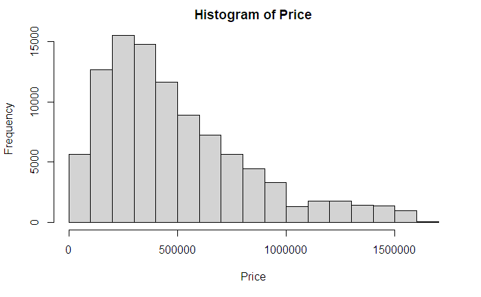

The `price` variable is positively skewed with most of the values centering around $300K-400K and a lot of values roughly evenly distributed between $1M-1.6M.

### Boxplot (price)

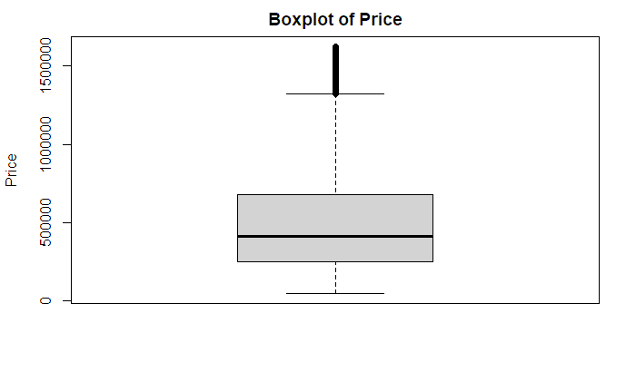

### Missing Prices

To find the percentage of missing `price` values from the unique entries, we can write:

```r
# compute the number of NA values and divide by the total number of values
ratio <- length(which(is.na(u_realtor$price))) / length(u_realtor$price)

# multiply by 100 and add a '%' to the end
paste(ratio * 100, "%", sep = "")
```

```
[1] "0.0158187522519751%"
```

## Data Conversion

### Date Conversion

We can add two new columns to the dataset that store the `sold_month` and the `sold_year` that the property was sold (if at all) by writing the following code:

```r
# turn the sold_date values into Date objects
formatted_dates <- as.Date(non_outliers$sold_date, format = "%Y-%m-%d")

# extract the month and year from the Dates
months <- format(formatted_dates, "%m")
years <- format(formatted_dates, "%Y")

# add the months and years as their own columns into the dataset
d_realtor <- non_outliers
d_realtor["sold_month"] <- months
d_realtor["sold_year"] <- years
```

and we can print the entries that contain a `sold_date` with this code:

```r
# retrieve the values that contain a sold_month value to determine which properties have and have not been sold
is_sold <- d_realtor[which(!is.na(d_realtor$sold_month)),]

# only display properties that have been sold
print(is_sold)
```

|  | status | price | bed | bath | acre_lot | full_address | street | city | state | zip_code | house_size | sold_date | sold_month | sold_year |
| --- | --- | --- | --- | --- | --- | --- | --- | --- | --- | --- | --- | --- | --- | --- |
| 685 | for_sale | 76900 | 3 | 2 | NA | E 331 Apt E 331 Alborada Unit E331, Canovanas, PR, 00729 | E 331 Apt E 331 Alborada Unit E331 | Canovanas | Puerto Rico | 729 | 1200 | 2020-02-28 | 02 | 2020 |
| 830 | for_sale | 110000 | 7 | 3 | 0.09 | B-2 Monte Elena, Dorado, PR, 00949 | B-2 Monte Elena | Dorado | Puerto Rico | 949 | 1192 | 2019-06-28 | 06 | 2019 |
| 4609 | for_sale | 159000 | 3 | 2 | NA | 784 Carretera Unit B302, Caguas, PR, 00725 | 784 Carretera Unit B302 | Caguas | Puerto Rico | 725 | 1625 | 2021-09-15 | 09 | 2021 |
| 5164 | for_sale | 380000 | NA | NA | 78.66 | Km 12 5 Carretera 182 Km 12 5 Bo Guayabota Yabucoa, Yabucoa, PR, 00767 | Km 12 5 Carretera 182 Km 12 5 Bo Guayabota Yabucoa | Yabucoa | Puerto Rico | 767 | NA | 2021-03-15 | 03 | 2021 |
| 10345 | for_sale | 950000 | 5 | 4 | 0.99 | 46 Water Isle, Saint Thomas, VI, 00802 | 46 Water Isle | Saint Thomas | Virgin Islands | 802 | 5000 | 2013-10-11 | 10 | 2013 |
| 11531 | for_sale | 79500 | NA | NA | 0.76 | 240 Cotton Vly # Eb, Christiansted, VI, 00820 | 240 Cotton Vly # Eb | Christiansted | Virgin Islands | 820 | NA | 2016-04-28 | 04 | 2016 |
| 11624 | for_sale | 176500 | NA | NA | 0.50 | 3 Teagues Bay Eb, Christiansted, VI, 00820 | 3 Teagues Bay Eb | Christiansted | Virgin Islands | 820 | NA | 2016-11-16 | 11 | 2016 |
| 14728 | for_sale | 129000 | NA | NA | 6.30 | 231 Little La Grange, Frederiksted, VI, 00840 | 231 Little La Grange | Frederiksted | Virgin Islands | 840 | NA | 2010-01-26 | 01 | 2010 |
| 18172 | for_sale | 1225000 | 6 | 5 | NA | Street C-2 Los Paseos Paseo Alto Unit 22, San Juan, PR, 00926 | Street C-2 Los Paseos Paseo Alto Unit 22 | San Juan | Puerto Rico | 926 | 4210 | 2022-03-18 | 03 | 2022 |
| 18306 | for_sale | 73400 | 3 | 1 | NA | Vista Buena Bo Sabana Seca St Unit C76, Toa Baja, PR, 00949 | Vista Buena Bo Sabana Seca St Unit C76 | Toa Baja | Puerto Rico | 949 | 950 | 2022-02-28 | 02 | 2022 |

[output cut: 990 more lines]

### State Conversion

We can convert the `state` attribute to a factor and print out the summary using the following code:

```r
# convert the state attribute to a factor
states = as.factor(d_realtor$state)

# replace the old column with the new factor
d_realtor["state"] <- states
summary(states)
```

```
   Connecticut       Delaware        Georgia          Maine  Massachusetts  New Hampshire     New Jersey
         12657           1262              5           4008           8642           3230          30307
      New York   Pennsylvania    Puerto Rico   Rhode Island        Vermont Virgin Islands       Virginia
         21532           8509           2297           3245           2201            605              7
 West Virginia        Wyoming
             1              1
```

From here, we can remove the entries where the `state` only appears once by writing

```r
# only allow states that have more than one appearance in the data
# we locate duplicates both from first->last and last->first as the first value is never considered a duplicate
s_realtor <- d_realtor[which(duplicated(d_realtor$state) | duplicated(d_realtor$state, fromLast=T)),]

# remove states that no longer have entries in the table
s_realtor["state"] <- droplevels(s_realtor$state)
summary(s_realtor$state)
```

```
   Connecticut       Delaware        Georgia          Maine  Massachusetts  New Hampshire     New Jersey
         12657           1262              5           4008           8642           3230          30307
      New York   Pennsylvania    Puerto Rico   Rhode Island        Vermont Virgin Islands       Virginia
         21532           8509           2297           3245           2201            605              7
```

Now every entry of a `state` that only appeared once in the dataset now does not appear at all in the dataset.

## Statistical Analysis

### Side-by-Side Boxplots

We can measure the differences in `price` based on the `state` that the property is in.

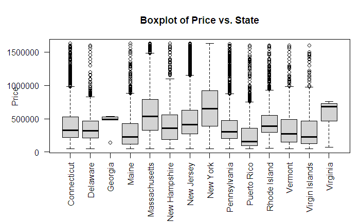

```r
# set plot margins to prevent text cutoff
par(mar = c(7, 5, 4, 1))
plot(s_realtor$price~s_realtor$state, xlab = "", ylab = "Price", main = "Boxplot of Price vs. State", las = 2, na.rm=T)
```

Here we can clearly see that there is a clear difference in `price` distribution based on the `state`. For example, the boxplot for the `state` `Virginia` shows that 75% of the data exists between $4.645^{5} and $7.55^{5} , whereas the boxplot for the `state` `Puerto Rico` shows that 75% of the data exists entirely between $5.03^{4} and $3.6^{5} .

### ANOVA Test

To mathematically confirm this, we can perform a one-way ANOVA test.

```r
anova <- oneway.test(s_realtor$price~s_realtor$state)
print(anova)
```

```
    One-way analysis of means (not assuming equal variances)

data:  s_realtor$price and s_realtor$state
F = 901.69, num df = 13.00, denom df = 154.44, p-value < 2.2e-16
```

Here, we get a `p-value` of 2.2902338^{-138}, which is less than the $\alpha$ value of 0.05 (and in fact we can go much, much smaller than that, as the $\alpha$ value used in the built-in ANOVA test is 2.2e-16), meaning there is a statistically significant difference between the average house price for different states.

### Spearman Rank Correlation

To determine the correlation between two numeric variables, we can perform the Spearman Rank correlation test between each pair of variables. This results in the following four code chunks:

#### Sold Year

```r
cor(y=s_realtor$price, x=as.numeric(s_realtor$sold_year), method="spearman", use="pairwise.complete.obs")
```

```
[1] -0.00778437
```

Since the value of the coefficient is a very small negative number, we can conclude that there is statistically no correlation between the year the property was sold and its price.

#### House Size

```r
cor(y=s_realtor$price, x=s_realtor$house_size, method="spearman", use="pairwise.complete.obs")
```

```
[1] 0.427162
```

For the house size, we can see that the coefficient is significantly larger at $\approx$ 0.43. This indicates there is a moderate positive correlation between house size and price.

#### Bed

```r
cor(y=s_realtor$price, x=s_realtor$bed, method="spearman", use="pairwise.complete.obs")
```

```
[1] 0.2436299
```

For the number of beds, we can see that the coefficient is not as large at only $\approx$ 0.24. This indicates there is a weak positive correlation between number of beds and price.

#### Bath

```r
cor(y=s_realtor$price, x=s_realtor$bath, method="spearman", use="pairwise.complete.obs")
```

```
[1] 0.4406539
```

For the number of baths, we can see that the coefficient is also $\approx$ 0.44. This indicates there is a moderate positive correlation between number of baths and price.

# Problem 2: Exploring Airline Dataset

## Data Summary

### Structure

```r
airline <- read.csv("airline_satisfaction.csv")
summary(airline)
```

```
       X                id            Gender          Customer.Type           Age        Type.of.Travel
 Min.   :     0   Min.   :     1   Length:103904      Length:103904      Min.   : 7.00   Length:103904
 1st Qu.: 25976   1st Qu.: 32534   Class :character   Class :character   1st Qu.:27.00   Class :character
 Median : 51952   Median : 64857   Mode  :character   Mode  :character   Median :40.00   Mode  :character
 Mean   : 51952   Mean   : 64924                                         Mean   :39.38
 3rd Qu.: 77927   3rd Qu.: 97368                                         3rd Qu.:51.00
 Max.   :103903   Max.   :129880                                         Max.   :85.00

    Class           Flight.Distance Inflight.wifi.service Departure.Arrival.time.convenient Ease.of.Online.booking
 Length:103904      Min.   :  31    Min.   :0.00          Min.   :0.00                      Min.   :0.000
 Class :character   1st Qu.: 414    1st Qu.:2.00          1st Qu.:2.00                      1st Qu.:2.000
 Mode  :character   Median : 843    Median :3.00          Median :3.00                      Median :3.000
                    Mean   :1189    Mean   :2.73          Mean   :3.06                      Mean   :2.757
                    3rd Qu.:1743    3rd Qu.:4.00          3rd Qu.:4.00                      3rd Qu.:4.000
                    Max.   :4983    Max.   :5.00          Max.   :5.00                      Max.   :5.000

 Gate.location   Food.and.drink  Online.boarding  Seat.comfort   Inflight.entertainment On.board.service
 Min.   :0.000   Min.   :0.000   Min.   :0.00    Min.   :0.000   Min.   :0.000          Min.   :0.000
 1st Qu.:2.000   1st Qu.:2.000   1st Qu.:2.00    1st Qu.:2.000   1st Qu.:2.000          1st Qu.:2.000
 Median :3.000   Median :3.000   Median :3.00    Median :4.000   Median :4.000          Median :4.000
 Mean   :2.977   Mean   :3.202   Mean   :3.25    Mean   :3.439   Mean   :3.358          Mean   :3.382
 3rd Qu.:4.000   3rd Qu.:4.000   3rd Qu.:4.00    3rd Qu.:5.000   3rd Qu.:4.000          3rd Qu.:4.000
 Max.   :5.000   Max.   :5.000   Max.   :5.00    Max.   :5.000   Max.   :5.000          Max.   :5.000

 Leg.room.service Baggage.handling Checkin.service Inflight.service  Cleanliness    Departure.Delay.in.Minutes
 Min.   :0.000    Min.   :1.000    Min.   :0.000   Min.   :0.00     Min.   :0.000   Min.   :   0.00
 1st Qu.:2.000    1st Qu.:3.000    1st Qu.:3.000   1st Qu.:3.00     1st Qu.:2.000   1st Qu.:   0.00
 Median :4.000    Median :4.000    Median :3.000   Median :4.00     Median :3.000   Median :   0.00
 Mean   :3.351    Mean   :3.632    Mean   :3.304   Mean   :3.64     Mean   :3.286   Mean   :  14.82
 3rd Qu.:4.000    3rd Qu.:5.000    3rd Qu.:4.000   3rd Qu.:5.00     3rd Qu.:4.000   3rd Qu.:  12.00
 Max.   :5.000    Max.   :5.000    Max.   :5.000   Max.   :5.00     Max.   :5.000   Max.   :1592.00

 Arrival.Delay.in.Minutes satisfaction
 Min.   :   0.00          Length:103904
 1st Qu.:   0.00          Class :character
 Median :   0.00          Mode  :character
 Mean   :  15.18
 3rd Qu.:  13.00
 Max.   :1584.00
 NA's   :310
```

```r
str(airline)
```

```
'data.frame':   103904 obs. of  25 variables:
 $ X                                : int  0 1 2 3 4 5 6 7 8 9 ...
 $ id                               : int  70172 5047 110028 24026 119299 111157 82113 96462 79485 65725 ...
 $ Gender                           : chr  "Male" "Male" "Female" "Female" ...
 $ Customer.Type                    : chr  "Loyal Customer" "disloyal Customer" "Loyal Customer" "Loyal Customer" ...
 $ Age                              : int  13 25 26 25 61 26 47 52 41 20 ...
 $ Type.of.Travel                   : chr  "Personal Travel" "Business travel" "Business travel" "Business travel" ...
 $ Class                            : chr  "Eco Plus" "Business" "Business" "Business" ...
 $ Flight.Distance                  : int  460 235 1142 562 214 1180 1276 2035 853 1061 ...
 $ Inflight.wifi.service            : int  3 3 2 2 3 3 2 4 1 3 ...
 $ Departure.Arrival.time.convenient: int  4 2 2 5 3 4 4 3 2 3 ...
 $ Ease.of.Online.booking           : int  3 3 2 5 3 2 2 4 2 3 ...
 $ Gate.location                    : int  1 3 2 5 3 1 3 4 2 4 ...
 $ Food.and.drink                   : int  5 1 5 2 4 1 2 5 4 2 ...
 $ Online.boarding                  : int  3 3 5 2 5 2 2 5 3 3 ...
 $ Seat.comfort                     : int  5 1 5 2 5 1 2 5 3 3 ...
 $ Inflight.entertainment           : int  5 1 5 2 3 1 2 5 1 2 ...
 $ On.board.service                 : int  4 1 4 2 3 3 3 5 1 2 ...
 $ Leg.room.service                 : int  3 5 3 5 4 4 3 5 2 3 ...
 $ Baggage.handling                 : int  4 3 4 3 4 4 4 5 1 4 ...
 $ Checkin.service                  : int  4 1 4 1 3 4 3 4 4 4 ...
 $ Inflight.service                 : int  5 4 4 4 3 4 5 5 1 3 ...
 $ Cleanliness                      : int  5 1 5 2 3 1 2 4 2 2 ...
 $ Departure.Delay.in.Minutes       : int  25 1 0 11 0 0 9 4 0 0 ...
 $ Arrival.Delay.in.Minutes         : num  18 6 0 9 0 0 23 0 0 0 ...
 $ satisfaction                     : chr  "neutral or dissatisfied" "neutral or dissatisfied" "satisfied" "neutral or dissatisfied" ...
```

### Variable Types

`X`: ordinal discrete  
`id`: ordinal discrete  
`Gender`: nominal categorical  
`Customer.Type`: nominal categorical  
`Age`: ordinal discrete  
`Type.of.Travel`: nominal categorical  
`Class`: ordinal categorical  
`Flight.Distance`: ordinal discrete  
`Inflight.wifi.service`: ordinal discrete  
`Departure.Arrival.time.convenient`: ordinal discrete  
`Ease.of.Online.booking`: ordinal discrete  
`Gate.location`: ordinal discrete  
`Food.and.drink`: ordinal discrete  
`Online.boarding`: ordinal discrete  
`Seat.comfort`: ordinal discrete  
`Inflight.entertainment`: ordinal discrete  
`On.board.service`: ordinal discrete  
`Leg.room.service`: ordinal discrete  
`Baggage.handling`: ordinal discrete  
`Checkin.service`: ordinal discrete  
`Inflight.service`: ordinal discrete  
`Cleanliness`: ordinal discrete  
`Departure.Delay.in.Minutes`: ordinal discrete  
`Arrival.Delay.in.Minutes`: ordinal discrete  
`satisfaction`: ordinal discrete

### Missing Values

We can display the column headers of the dataset by selecting the columns where the sum of entries that are `NA` is greater than 0 and printing their names.

```r
# display the names of columns where the sum of NA values is greater than 0
names(which(colSums(is.na(airline)) > 0))
```

```
[1] "Arrival.Delay.in.Minutes"
```

## Remove `id` and `X`

```r
airline$X <- NULL
airline$id <- NULL
```

## Data Analysis (Satisfaction)

### Mosaic Plots and ChiSquare Tests | Spearman Rank Correlations

We can perform a Mosaic Plot and ChiSquare test on the nominal data and the Spearman Rank correlations on the ordinal data using the followng code:

```
   Cell Contents
|-------------------------|
|                       N |
| Chi-square contribution |
|           N / Row Total |
|           N / Col Total |
|         N / Table Total |
|-------------------------|


Total Observations in Table:  103904


             | satisfaction
      otherC | neutral or dissatisfied |               satisfied |               Row Total |
-------------|-------------------------|-------------------------|-------------------------|
      Female |                   30193 |                   22534 |                   52727 |
             |                   3.307 |                   4.324 |                         |
             |                   0.573 |                   0.427 |                   0.507 |
             |                   0.513 |                   0.500 |                         |
             |                   0.291 |                   0.217 |                         |
-------------|-------------------------|-------------------------|-------------------------|
        Male |                   28686 |                   22491 |                   51177 |
             |                   3.407 |                   4.455 |                         |
             |                   0.561 |                   0.439 |                   0.493 |
             |                   0.487 |                   0.500 |                         |
             |                   0.276 |                   0.216 |                         |
-------------|-------------------------|-------------------------|-------------------------|
Column Total |                   58879 |                   45025 |                  103904 |
             |                   0.567 |                   0.433 |                         |
-------------|-------------------------|-------------------------|-------------------------|


Statistics for All Table Factors


Pearson's Chi-squared test
------------------------------------------------------------
Chi^2 =  15.49367     d.f. =  1     p =  8.278206e-05

Pearson's Chi-squared test with Yates' continuity correction
------------------------------------------------------------
Chi^2 =  15.44442     d.f. =  1     p =  8.496755e-05
```

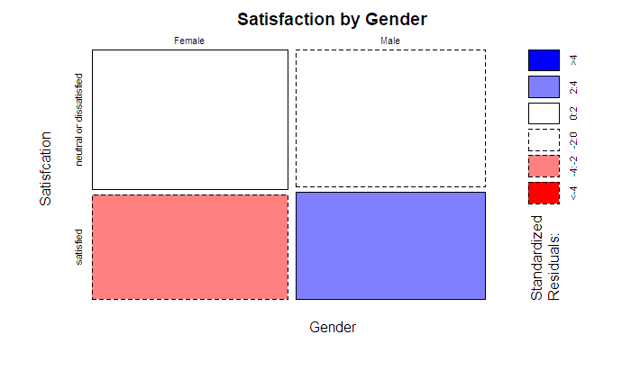

```
   Cell Contents
|-------------------------|
|                       N |
| Chi-square contribution |
|           N / Row Total |
|           N / Col Total |
|         N / Table Total |
|-------------------------|


Total Observations in Table:  103904


                  | satisfaction
           otherC | neutral or dissatisfied |               satisfied |               Row Total |
------------------|-------------------------|-------------------------|-------------------------|
disloyal Customer |                   14489 |                    4492 |                   18981 |
                  |                1295.654 |                1694.322 |                         |
                  |                   0.763 |                   0.237 |                   0.183 |
                  |                   0.246 |                   0.100 |                         |
                  |                   0.139 |                   0.043 |                         |
------------------|-------------------------|-------------------------|-------------------------|
   Loyal Customer |                   44390 |                   40533 |                   84923 |
                  |                 289.590 |                 378.695 |                         |
                  |                   0.523 |                   0.477 |                   0.817 |
                  |                   0.754 |                   0.900 |                         |
                  |                   0.427 |                   0.390 |                         |
------------------|-------------------------|-------------------------|-------------------------|
     Column Total |                   58879 |                   45025 |                  103904 |
                  |                   0.567 |                   0.433 |                         |
------------------|-------------------------|-------------------------|-------------------------|


Statistics for All Table Factors


Pearson's Chi-squared test
------------------------------------------------------------
Chi^2 =  3658.261     d.f. =  1     p =  0

Pearson's Chi-squared test with Yates' continuity correction
------------------------------------------------------------
Chi^2 =  3657.281     d.f. =  1     p =  0
```

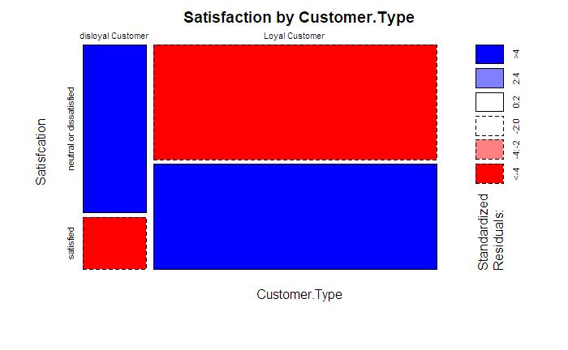

```
   Cell Contents
|-------------------------|
|                       N |
| Chi-square contribution |
|           N / Row Total |
|           N / Col Total |
|         N / Table Total |
|-------------------------|


Total Observations in Table:  103904


                | satisfaction
         otherC | neutral or dissatisfied |               satisfied |               Row Total |
----------------|-------------------------|-------------------------|-------------------------|
Business travel |                   29909 |                   41746 |                   71655 |
                |                2817.288 |                3684.156 |                         |
                |                   0.417 |                   0.583 |                   0.690 |
                |                   0.508 |                   0.927 |                         |
                |                   0.288 |                   0.402 |                         |
----------------|-------------------------|-------------------------|-------------------------|
Personal Travel |                   28970 |                    3279 |                   32249 |
                |                6259.815 |                8185.933 |                         |
                |                   0.898 |                   0.102 |                   0.310 |
                |                   0.492 |                   0.073 |                         |
                |                   0.279 |                   0.032 |                         |
----------------|-------------------------|-------------------------|-------------------------|
   Column Total |                   58879 |                   45025 |                  103904 |
                |                   0.567 |                   0.433 |                         |
----------------|-------------------------|-------------------------|-------------------------|


Statistics for All Table Factors


Pearson's Chi-squared test
------------------------------------------------------------
Chi^2 =  20947.19     d.f. =  1     p =  0

Pearson's Chi-squared test with Yates' continuity correction
------------------------------------------------------------
Chi^2 =  20945.23     d.f. =  1     p =  0
```

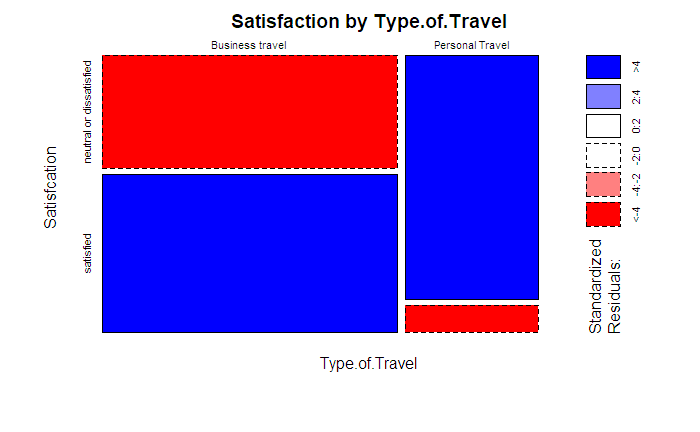

```r
# for each column in the airline dataset, determine the classification of the data by referring to the cat vector and run the appropriate test based on that value
c <- 1
while(c < length(airline)){
  otherC <- airline[,c]
  otherN <- colnames(airline[c])

  #skip class, as the data represents ordinal values but is not formatted numerically
  if(otherN == "Class"){
    c <- c + 1
    next
  }
  if(cat[c] == n){
    # nominal value, use mosaic plot and chi-sq test
    mosaicplot(table(otherC, satisfaction), xlab = otherN, ylab = "Satisfcation", main = paste("Satisfaction by", otherN), shade=T)
    CrossTable(otherC, satisfaction, chisq=T)
  }else{
    # ordinal value, use Spearman rank correlation instead
    spearman_vals[otherN] <- cor(y=as.numeric(ordinal_satisfaction), x=as.numeric(otherC), method="spearman", use="pairwise.complete.obs")
  }
  c <- c + 1
}
```

```r
# remove placeholder value from vector
spearman_vals[1] <- NULL

# manually run remaining ordinal class vector
spearman_vals["Class"] <- cor(y=as.numeric(ordinal_satisfaction), x=as.numeric(ordinal_class), method="spearman", use="pairwise.complete.obs")

print(spearman_vals)
```

| Ease.of.Online.booking | Gate.location | Food.and.drink | Online.boarding | Seat.comfort | Inflight.entertainment | On.board.service | Leg.room.service | Baggage.handling | Checkin.service | Inflight.service | Cleanliness | Departure.Delay.in.Minutes | Arrival.Delay.in.Minutes | Class | Age | Flight.Distance | Inflight.wifi.service |
| --- | --- | --- | --- | --- | --- | --- | --- | --- | --- | --- | --- | --- | --- | --- | --- | --- | --- |
| 0.177121 | -0.0001374372 | 0.207237 | 0.5509942 | 0.3621988 | 0.3995042 | 0.3283012 | 0.3183433 | 0.2693177 | 0.2326025 | 0.2653621 | 0.3034295 | -0.0679133 | -0.1005186 | 0.4951728 | 0.1471452 | 0.2572736 | 0.2874577 |

## Data Interpretations

### Mosaic Plots and ChiSquared Tests

#### Gender

According to the Mosaic Plot for Satisfaction by Gender, `Gender` seems to play the least important role in determining a customer’s satisfaction. There is a slightly higher tendency for males to report being satisfied, and a slightly lower tendency for females to report being satisfied, but ultimately the data is roughly even.  
According to the ChiSquared test, there is a statistically significant correlation between `Gender` and `satisfaction`, as the `p-value` is much lower than the $\alpha$ 0.05 at 8.27e-05.

#### Customer Type

The `Customer.Type` Mosaic reveals there is a much higher frequency of loyal customers that report being satisfied as opposed to disloyal customers, which is to be expected for such a statistic.  
The statistical significance is so great, in fact, that the `p-value` from the ChiSquared test is actually so low it is essentially 0. As a matter of fact, every other nominal value resulted in a p-value that is essentially 0, meaning `Gender` was the only variable with any shred of doubt as to its correlation.

#### Type of Travel

This Mosaic Plot contained the lowest frequency of satisfied customers, revealing that those who traveled for personal reasons were rarely satisfied, especially compared to those who traveled for business, who were satisfied significantly more frequently than 50% of the time.  
As mentioned before, this ChiSquared test also resulted in a `p-value` of 0, implying a heavy bivariate correlation.

#### Mosaic Conclusions

Unfortunately, these nominal categories are not something the airline can completely control: Gender is set per customer, as well as their reason for travel, and brand loyalty is not something that can really be established with a customer that is typically disloyal without exceptional and unmatched service. Areas to look for improvement should be those in the Spearman Rank correlations.